# F1-Solution

```python
#Meiiansam-F1-solution
```

```python
import numpy as np
import matplotlib.pyplot as plt
```

(a) sol: The sine-cosine Fourier expandsion: \begin{equation} f(x) = \frac{1}{2}a_{0} + \sum_{n=1}^{\infty}a_{n}\cos{\frac{2n\pi x}{L}} +\sum_{n=1}^{\infty}b_{n}\sin{\frac{2n\pi x}{L}} \end{equation} \ In this case, $L = 2\pi$: \begin{equation} f(x) = \frac{1}{2}a_{0} + \sum_{n=1}^{\infty}a_{n}\cos{nx} +\sum_{n=1}^{\infty}b_{n}\sin{nx} \end{equation} \ \begin{equation} a_{0} = \frac{1}{\pi}\int^{\pi}_{-\pi} f(x) dx = \frac{1}{\pi}\int^{\pi}_{0} x dx = \frac{\pi}{2} \end{equation} \ \begin{eqnarray} a_{n} &=& \frac{2}{L}\int^{L/2}_{-L/2} f(x)\cos \frac{2n\pi}{L} dx\\ &=& \frac{1}{\pi}\int^{\pi}_{0} x\cos(nx)dx\\ &=& \frac{1}{\pi}(\frac{1}{n}x\sin(x) \Big{|}^{\pi}_{0}- \int^{\pi}_{0}\frac{1}{n}\sin(nx)dx)\\ &=& \frac{1}{\pi}\frac{1}{n^{2}}(\cos{n\pi}-1)\\ &=& \frac{(-1)^{n}-1}{\pi n^{2}} \end{eqnarray} \ \begin{eqnarray} b_{n} &=& \frac{2}{L}\int^{L/2}_{-L/2} f(x)\sin \frac{2n\pi}{L} dx\\ &=& \frac{1}{\pi}\int^{\pi}_{0} x\sin(nx)dx\\ &=& \frac{1}{\pi}(-\frac{1}{n}x\cos(x) \Big{|}^{\pi}_{0}- \int^{\pi}_{0}\frac{1}{n}\cos(nx)dx)\\ &=& -\frac{1}{\pi}\frac{\pi}{n}\cos{n\pi}\\ &=& \frac{(-1)^{n+1}}{n} \end{eqnarray} We have: \begin{equation} f(x) = \frac{\pi}{4} + \sum_{n=1}^{\infty}\frac{(-1)^{n}-1}{\pi n^{2}}\cos{nx} +\sum_{n=1}^{\infty}\frac{(-1)^{n+1}}{n}\sin{nx} \end{equation}

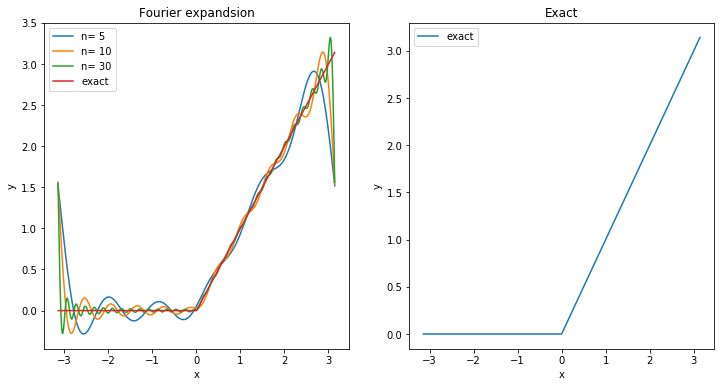

```python
pi = np.pi
xs = np.linspace(-pi,pi,1000)
fig = plt.figure(figsize=(12,6))

###Fourier-series###
plt.subplot(1,2,1)
steps = [5,10,30]
fs = []
for step in steps:
    fs = []
    for x in xs:
        f=pi/4
        for n in range(1,step+1):
            an = ((-1)**n -1)/(pi*(n**2))
            bn = ((-1)**(n+1))/n
            f = f + an*np.cos(n*x) + bn*np.sin(n*x)
        fs.append(f)
    plt.plot(xs,fs,label = 'n= %d'%step)
    plt.legend()
plt.xlabel('x')
plt.ylabel('y')
plt.title('Fourier expandsion')
####################

###exact###
plt.subplot(1,2,1)
temp1 = [0 for x in xs if x<0]
temp2 = [x for x in xs if x>0]
ys = temp1+temp2
plt.plot(xs,ys,label = 'exact')
plt.legend()
plt.subplot(1,2,2)
plt.plot(xs,ys,label = 'exact')
plt.legend()
plt.xlabel('x')
plt.ylabel('y')
plt.title('Exact')
##########
```

(c) sol:\ By the Dirichlet's theorem, we know f(x=0) converge to zero, we have: \begin{equation} f(0) = \frac{\pi}{4} + \sum_{n=1}^{\infty}\frac{(-1)^{n}-1}{\pi n^{2}} = 0 \end{equation} The later term vanishes when n is a even number. \begin{eqnarray} \frac{\pi}{4} + \sum_{n=odd}^{\infty}\frac{-2}{\pi n^{2}} &=& 0\\ \sum_{n=odd}^{\infty}\frac{1}{n^{2}} &=& \frac{\pi ^2}{8} \end{eqnarray}